# ds202_lab4

Lisa McDaniel

10/9/2020

Loading Data:

```r
library(readxl)
library(tidyverse)

defense <- read_excel('C:/Users/lisa.mcdaniel/DS202/ds202lab4/cyclonesFootball2019.xlsx',
                      sheet="Defensive")

offense <- read_excel('C:/Users/lisa.mcdaniel/DS202/ds202lab4/cyclonesFootball2019.xlsx',
                      sheet="Offensive")

bio <- read_excel('C:/Users/lisa.mcdaniel/DS202/ds202lab4/cyclonesFootball2019.xlsx',
                      sheet="Biography")
```

Part One: Cleaning Data

1. The player names and opponent names are factors.

```r
def1 <- defense %>%
  mutate(Name = as.factor(Name),
         Opponent_Opponent = as.factor(Opponent_Opponent))

off1 <- offense %>%
  mutate(Name = as.factor(Name),
         Opponent_Opponent = as.factor(Opponent_Opponent))

bio1 <-  bio %>%
  mutate(Name = as.factor(Name))
```

2. All offensive and defensive statistics are numerical. The Weight column in biogrpahy is also numeric. (Optional: Learn to mutate multiple columns systematically using the ?across function in `dplyr)

```r
defClean <- def1 %>%
  mutate(across(.cols = (Tackles_Solo:Pass_PB), .fns = (as.numeric)))

offClean <- off1 %>%
  separate(`Passing_CMP-ATT`, c('Passing_CMP', 'Passing_ATT')) %>%
  mutate(across(.cols = (Rushing_ATT:Passing_INT), .fns = (as.numeric)))

bio2 <- bio1 %>%
  mutate(Weight = as.numeric(Weight))
```

3. Change the Height column in biogrpahy into numeric. (Hint: Use a unit that works well).

Converted the height to inches; column heading *Height_in*. Only showing the first 6 rows of the *bioClean* dataframe.

```r
bioClean <- bio2 %>%
 separate(Height, c('feet', 'inches'), sep = '-') %>%
 mutate(feet = as.numeric(feet), inches = as.numeric(inches)) %>%
 mutate(Height_in = (12*feet + inches)) %>%
 select(-feet, -inches)

head(bioClean)
```

```
## # A tibble: 6 x 7
##   Name         Position    Weight Class       Hometown      Highschool Height_in
##   <fct>        <chr>        <dbl> <chr>       <chr>         <chr>          <dbl>
## 1 Akers, Land~ Wide Recei~    188 Redshirt S~ Cedar Rapids~ Washington        72
## 2 Allen, Chase Tight End      245 Redshirt S~ Nixa, Mo.     Nixa              79
## 3 Anderson, E~ Wide Recei~    204 Redshirt F~ Seffner, Fla. Armwood           77
## 4 Assalley, C~ Placekicker    195 Redshirt S~ Naperville, ~ Central           72
## 5 Azunna, Arn~ Defensive ~    190 Redshirt S~ Grand Prairi~ Lake Ridge        72
## 6 Bailey, Cor~ Defensive ~    235 Redshirt J~ Clarksdale, ~ Clarksdale        75
```

Cleaned Dataframes

```r
str(defClean)
```

```
## tibble [502 x 11] (S3: tbl_df/tbl/data.frame)
##  $ Name             : Factor w/ 43 levels "Akers, Landen",..: 40 40 40 40 40 40 40 40 40 40 ...
##  $ Opponent_Opponent: Factor w/ 13 levels "Baylor","Iowa",..: 12 2 11 1 8 13 10 7 6 9 ...
##  $ Tackles_Solo     : num [1:502] 4 4 3 4 3 1 7 3 6 5 ...
##  $ Tackles_ASST     : num [1:502] 4 7 5 2 2 1 1 2 1 5 ...
##  $ Tackles_TFL      : num [1:502] 0 0 0 0 1 0 0 0 1 1 ...
##  $ Tackles_Sack     : num [1:502] 0 0 0 0 0 0 0 0 0 1 ...
##  $ Turnover_FF      : num [1:502] 0 0 0 0 0 0 0 0 0 0 ...
##  $ Turnover_FR      : num [1:502] 0 0 0 0 0 0 0 0 0 0 ...
##  $ Turnover_INT     : num [1:502] 0 0 1 0 0 0 0 0 1 0 ...
##  $ Pass_QBH         : num [1:502] 1 0 0 0 0 0 0 0 1 0 ...
##  $ Pass_PB          : num [1:502] 1 2 0 0 0 1 0 0 0 0 ...
```

```r
str(offClean)
```

```
## tibble [195 x 13] (S3: tbl_df/tbl/data.frame)
##  $ Name             : Factor w/ 17 levels "Akers, Landen",..: 1 1 1 1 1 1 1 1 1 1 ...
##  $ Opponent_Opponent: Factor w/ 13 levels "Baylor","Iowa",..: 12 2 11 1 8 13 10 7 6 9 ...
##  $ Rushing_ATT      : num [1:195] 0 0 1 0 0 0 0 0 0 0 ...
##  $ Rushing_YDS      : num [1:195] 0 0 8 0 0 0 0 0 0 0 ...
##  $ Rushing_TD       : num [1:195] 0 0 0 0 0 0 0 0 0 0 ...
##  $ Receiving_REC    : num [1:195] 1 0 0 0 1 0 0 4 0 1 ...
##  $ Receiving_YDS    : num [1:195] 21 0 0 0 32 0 0 39 0 7 ...
##  $ Receiving_TD     : num [1:195] 0 0 0 0 0 0 0 0 0 0 ...
##  $ Passing_CMP      : num [1:195] NA NA NA NA NA NA NA NA NA NA ...
##  $ Passing_ATT      : num [1:195] NA NA NA NA NA NA NA NA NA NA ...
##  $ Passing_YDS      : num [1:195] NA NA NA NA NA NA NA NA NA NA ...
##  $ Passing_TD       : num [1:195] NA NA NA NA NA NA NA NA NA NA ...
##  $ Passing_INT      : num [1:195] NA NA NA NA NA NA NA NA NA NA ...
```

```r
str(bioClean)
```

```
## tibble [105 x 7] (S3: tbl_df/tbl/data.frame)
##  $ Name      : Factor w/ 105 levels "Akers, Landen",..: 1 2 3 4 5 6 7 8 9 10 ...
##  $ Position  : chr [1:105] "Wide Receiver" "Tight End" "Wide Receiver" "Placekicker" ...
##  $ Weight    : num [1:105] 188 245 204 195 190 235 255 285 300 215 ...
##  $ Class     : chr [1:105] "Redshirt Senior" "Redshirt Senior" "Redshirt Freshman" "Redshirt Senior" ...
##  $ Hometown  : chr [1:105] "Cedar Rapids, Iowa" "Nixa, Mo." "Seffner, Fla." "Naperville, Ill." ...
##  $ Highschool: chr [1:105] "Washington" "Nixa" "Armwood" "Central" ...
##  $ Height_in : num [1:105] 72 79 77 72 72 75 74 74 72 78 ...
```

Part Two: Tidying

1. Reformat the defClean data frame into a tidy format using pivot_longer. The type of statistic (Tackles_Solo, Tackles_ASST, etc) is added as a new key column named stat.

Saved the new dataframe as *defClean1*; only showing the first 6 rows of the *defClean1* dataframe in the output.

```r
defClean1 <- defClean %>%
  pivot_longer(`Tackles_Solo`:`Pass_PB`, names_to='Def_Skill', values_to='Stat')

head(defClean1)
```

```
## # A tibble: 6 x 4
##   Name            Opponent_Opponent Def_Skill     Stat
##   <fct>           <fct>             <chr>        <dbl>
## 1 White, Lawrence UNI               Tackles_Solo     4
## 2 White, Lawrence UNI               Tackles_ASST     4
## 3 White, Lawrence UNI               Tackles_TFL      0
## 4 White, Lawrence UNI               Tackles_Sack     0
## 5 White, Lawrence UNI               Turnover_FF      0
## 6 White, Lawrence UNI               Turnover_FR      0
```

2. Compare the distributions of the defensive statistics. What defensive skills are rare?

Created a barplot showing the defensive skills and arranged the information in ascending order. The 3 rarest defensive skills are interception, fumble recovery and fumble, respectively, all are related to turnovers.

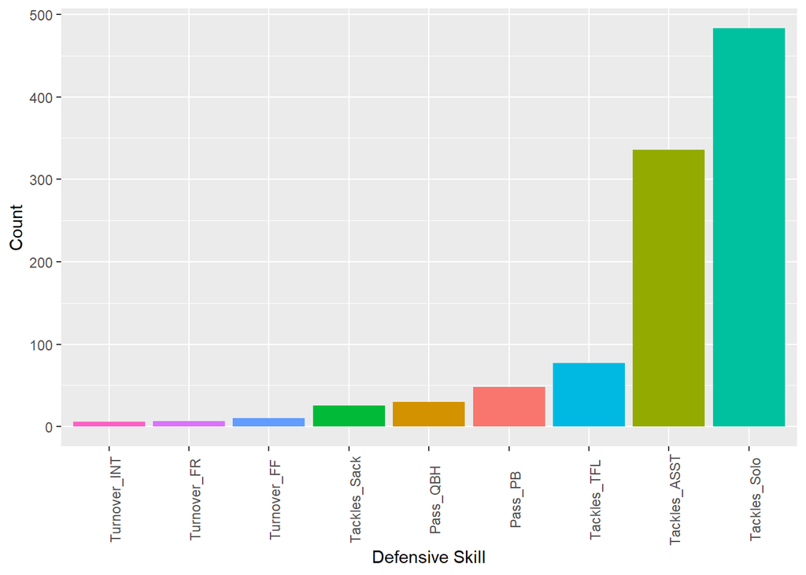

```r
skill <- c("Turnover_INT", "Turnover_FR", "Turnover_FF", "Tackles_Sack",
           "Pass_QBH", "Pass_PB", "Tackles_TFL", "Tackles_ASST", "Tackles_Solo")

ggplot(defClean1, aes(x=Def_Skill, y=Stat, fill=Def_Skill)) +
  geom_bar(stat= 'identity') + scale_x_discrete(limits = skill) +
  theme(axis.text.x = element_text(angle = 90)) + ylab("Count") +
  xlab("Defensive Skill") + theme(legend.position="none")
```

3. Did ISU have better defense against Iowa or Notre Dame? Answer this question by creating a scatterplot with x- and y-axes being the number of solo tackles (of each player). A large number of solo tackles is an indicator of good defense.

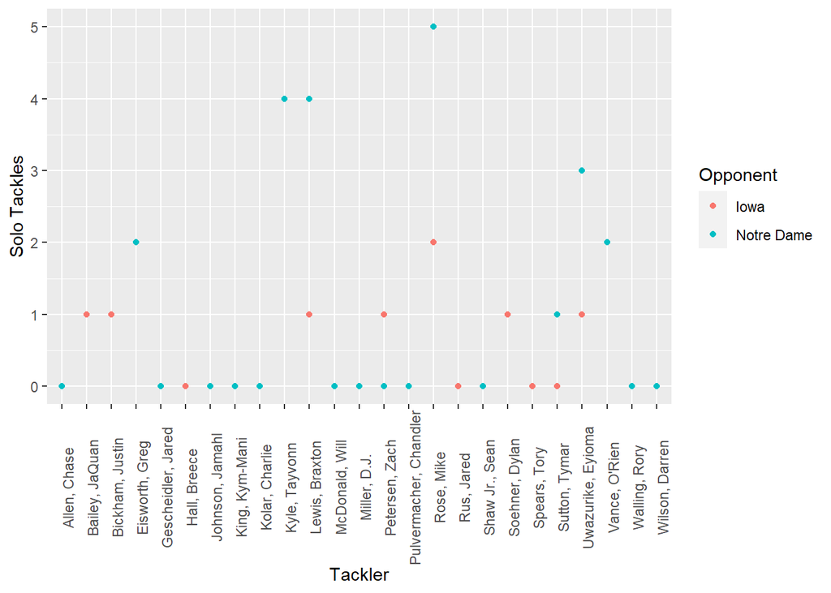

```r
defClean2 <- defClean1 %>%
  filter(Opponent_Opponent == c("Iowa", "Notre Dame"),
         Def_Skill == "Tackles_Solo")

ggplot(data=defClean2, aes(y=Stat, x=Name, color=Opponent_Opponent)) +
  geom_point() + theme(axis.text.x = element_text(angle = 90)) +
  ylab("Solo Tackles") + xlab('Tackler') + labs(color="Opponent")
```

4. Separate the Hometown column into two columns, namely the city and the state. Print the first few rows of these two columns. (Hint: look at the sep= argument of separate)

```r
bioClean1 <- bioClean %>%
  separate(Hometown, c('City', 'State'), sep = ',')

head(bioClean1[, c("City", "State")], n=5)
```

```
## # A tibble: 5 x 2
##   City          State
##   <chr>         <chr>
## 1 Cedar Rapids  " Iowa"
## 2 Nixa          " Mo."
## 3 Seffner       " Fla."
## 4 Naperville    " Ill."
## 5 Grand Prairie " Texas"
```

5. How many players are there from each state?

I created a dataframe called *St1* to store the state and number of players from each state, by state in alphabetical order. I’m only showing the first 6 rows in the output.

```r
St1 <- bioClean1 %>%
  select(Name, State) %>%
  count(State)

head(St1)
```

```
## # A tibble: 6 x 2
##   State            n
##   <chr>        <int>
## 1 " Ariz."         4
## 2 " Ark."          1
## 3 " Australia"     1
## 4 " Calif."        3
## 5 " Fla."         10
## 6 " Ga."           4
```

Part Three: Joining Data Frames

1. Find from which states do the ISU players come. Create an appropriate summary.

```r
St2 <- bioClean1 %>%
  select(Name, State) %>%
  group_nest(State) %>%
  as_tibble()

head(St2, n=5)
```

```
## # A tibble: 5 x 2
##   State                      data
##   <chr>        <list<tbl_df[,1]>>
## 1 " Ariz."                [4 x 1]
## 2 " Ark."                 [1 x 1]
## 3 " Australia"            [1 x 1]
## 4 " Calif."               [3 x 1]
## 5 " Fla."                [10 x 1]
```

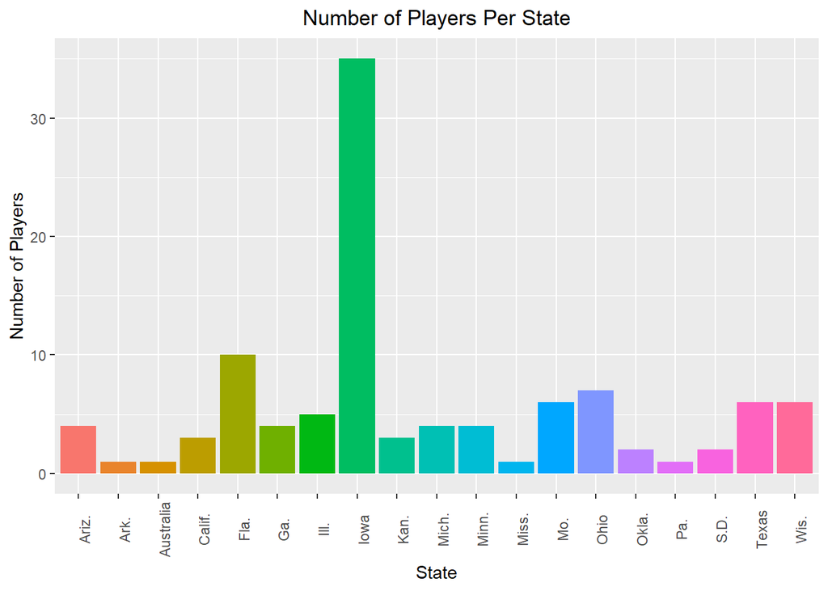

```r
ggplot(data=St1, aes(x=State,  y=n, fill=State)) +
  geom_bar(stat= 'identity') +  ggtitle("Number of Players Per State") +
  theme(plot.title = element_text(hjust = 0.5)) +  theme(legend.position="none") +
  theme(axis.text.x = element_text(angle = 90)) + ylab("Number of Players") +
  xlab("State")
```

2. Is there a relationship between the player statistics and their positions?

Defense: Using facet wrap, I created individual bar plots, by defensive position, to show there is a relationship between player statistics and position. For example, you can tell the Defensive Back and Linebacker both dominate tackle related defense skills.

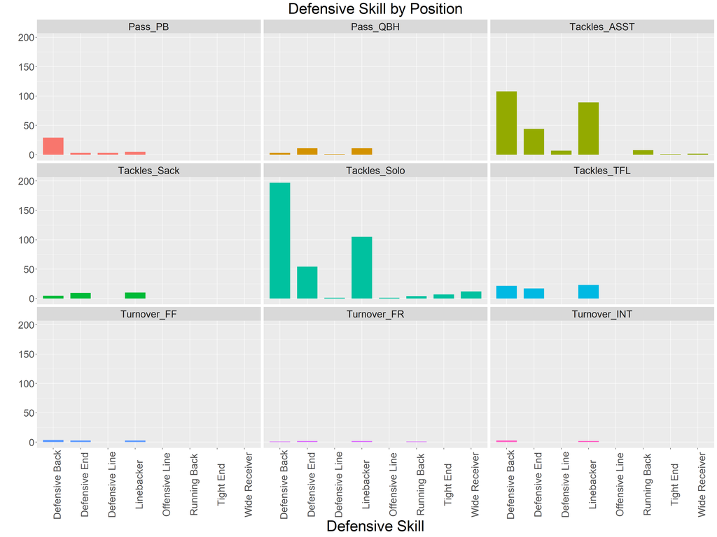

```r
bioClean3 <- bioClean %>%
  select(Name, Position)

defPos <- defClean %>%
  left_join(bioClean3) %>%
  select(-Opponent_Opponent, -Name) %>%
  group_by(Position) %>%
  filter(!is.na(Position)) %>%
  summarise_at(vars(Tackles_Solo:Pass_PB), sum, na.rm=TRUE) %>%
  pivot_longer('Tackles_Solo':'Pass_PB', names_to='Def_Skill',
               values_to='Stat')

ggplot(defPos, aes(Position, Stat, fill=Def_Skill)) +
  geom_bar(stat = "identity", position = 'dodge', width = .75) +
  ggtitle("Defensive Skill by Position") + theme(plot.title = element_text(size = 30)) +
  theme(plot.title = element_text(hjust = 0.5))  + theme(legend.position="none") +
  theme(axis.text.x = element_text(angle = 90)) + ylab("") +
  theme(axis.text = element_text(size = 20)) + theme(axis.title = element_text(size = 30)) +
  xlab("Defensive Skill") + facet_wrap(~Def_Skill) + theme(strip.text.x = element_text(size = 20))
```

Offense: Using facet wrap, I created individual bar plots, by offensive position, to show there is a relationship between player statistics and position. For example, you can tell the quarterback dominates passing related offense skills.

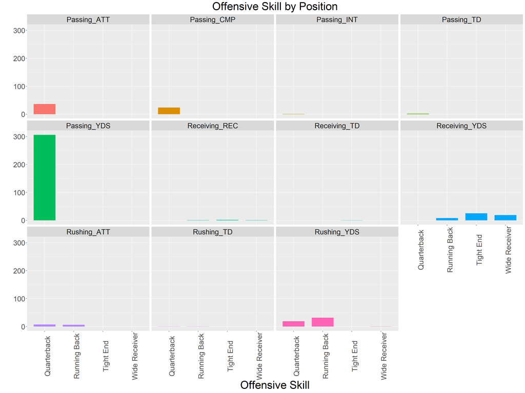

```r
offPos <- offClean %>%
  left_join(bioClean3) %>%
  select(-Opponent_Opponent, -Name) %>%
  group_by(Position) %>%
  filter(!is.na(Position)) %>%
  summarise_at(vars(Rushing_ATT:Passing_INT), mean, na.rm=TRUE) %>%
  pivot_longer('Rushing_ATT':'Passing_INT', names_to='Off_Skill',
               values_to='Stat')

ggplot(offPos, aes(Position, Stat, fill=Off_Skill)) +
  geom_bar(stat = "identity", position = 'dodge', width = .75) +
  ggtitle("Offensive Skill by Position") + theme(plot.title = element_text(size = 30)) +
  theme(plot.title = element_text(hjust = 0.5))  + theme(legend.position="none") +
  theme(axis.text.x = element_text(angle = 90)) + ylab("") +
  theme(axis.text = element_text(size = 20)) + theme(axis.title = element_text(size = 30)) +
  xlab("Offensive Skill") + facet_wrap(~Off_Skill) +theme(strip.text.x = element_text(size = 20))
```

3. How does the performance of quarterback Brock Purdy relate to the performance of the ISU team?

```r
offClean2 <- offClean %>%
  filter(Name == "Purdy, Brock") %>%
  select(-Receiving_REC, -Receiving_TD, -Receiving_YDS) %>%
  mutate(Rating = (((((Passing_CMP/Passing_ATT)-0.3)/0.2) +
           (((Passing_YDS/Passing_ATT)-3)/4) + ((Passing_TD/Passing_ATT)/0.05) +
  ((0.095-(Passing_INT/Passing_ATT))/0.04))*100)/6) %>%
  arrange(Rating) %>%
  mutate(W_L = ifelse(Opponent_Opponent %in% c('UNI', 'ULM', 'TCU', 'West Virginia', 'Texas Tech', 'Texas', 'Kansas'), 'W', 'L')) %>%
  select(Name, Opponent_Opponent, W_L, Rating)

offClean2
```

```
## # A tibble: 13 x 4
##    Name         Opponent_Opponent W_L   Rating
##    <fct>        <fct>             <chr>  <dbl>
##  1 Purdy, Brock Oklahoma State    L       65.4
##  2 Purdy, Brock Notre Dame        L       80.1
##  3 Purdy, Brock Kansas State      L       80.6
##  4 Purdy, Brock West Virginia     W       83.9
##  5 Purdy, Brock Baylor            L       89.3
##  6 Purdy, Brock Texas             W       90.1
##  7 Purdy, Brock Iowa              L      105.
##  8 Purdy, Brock UNI               W      108.
##  9 Purdy, Brock Kansas            W      118.
## 10 Purdy, Brock Texas Tech        W      129.
## 11 Purdy, Brock TCU               W      139.
## 12 Purdy, Brock Oklahoma          L      150.
## 13 Purdy, Brock ULM               W      156.
```

4. Which ISU player(s) made big progress over the last year? Compare the 2019 and the 2018 data here.

Defense: There were 28 players that played during both the 2018 and 2019 seasons, O’Rien Vance and Zach Petersen appear to show the most improvement in several defensive skills; JaQuan Baiey appears to be getting worse.

```r
defense2 <- read_excel('C:/Users/lisa.mcdaniel/DS202/ds202lab4/cyclonesFootball2018.xlsx',
                      sheet="Defensive")

offense2 <- read_excel('C:/Users/lisa.mcdaniel/DS202/ds202lab4/cyclonesFootball2018.xlsx',
                      sheet="Offensive")

defClean2N <- defense2 %>%
  select(Name) %>%
  distinct()

defClean3N <- defClean %>%
  select(Name) %>%
  distinct()

DefNames <- inner_join(defClean2N, defClean3N)

defClean2 <- defense2 %>%
  select(-Opponent_Opponent) %>%
  mutate(Name = as.factor(Name)) %>%
  mutate(across(.cols = (Tackles_Solo:Pass_PB), .fns = (as.numeric))) %>%
  group_by(Name) %>%
  summarise_at(vars(Tackles_Solo:Pass_PB), sum, na.rm=TRUE) %>%
  mutate(Year = '2018') %>%
  right_join(DefNames) %>%
  pivot_longer(`Tackles_Solo`:`Pass_PB`, names_to='Def_Skill',
               values_to='Stat')

defClean3 <- defClean %>%
  select(-Opponent_Opponent) %>%
  group_by(Name) %>%
  summarise_at(vars(Tackles_Solo:Pass_PB), sum, na.rm=TRUE) %>%
  mutate(Year='2019') %>%
  right_join(DefNames) %>%
  pivot_longer(`Tackles_Solo`:`Pass_PB`, names_to='Def_Skill',
               values_to='Stat')

defComp <- full_join(defClean2, defClean3)

head(defComp)
```

```
## # A tibble: 6 x 4
##   Name          Year  Def_Skill     Stat
##   <chr>         <chr> <chr>        <dbl>
## 1 Akers, Landen 2018  Tackles_Solo     1
## 2 Akers, Landen 2018  Tackles_ASST     0
## 3 Akers, Landen 2018  Tackles_TFL      0
## 4 Akers, Landen 2018  Tackles_Sack     0
## 5 Akers, Landen 2018  Turnover_FF      0
## 6 Akers, Landen 2018  Turnover_FR      0
```

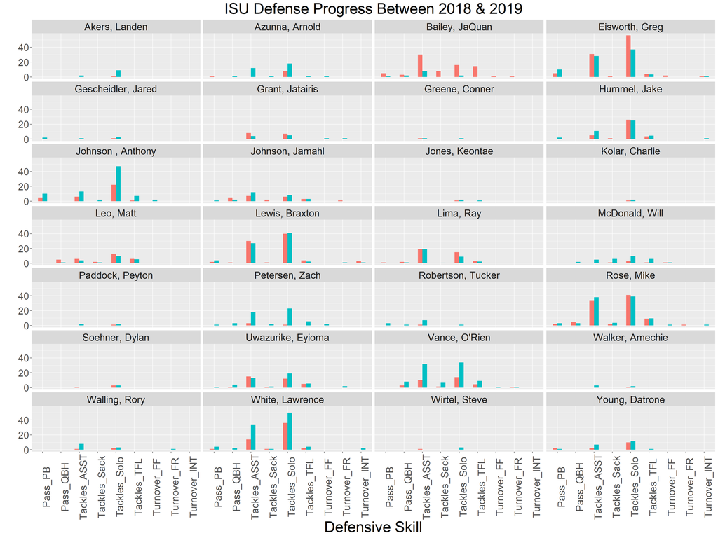

```r
ggplot(defComp, aes(Def_Skill, Stat, fill=Year)) +
  geom_bar(stat = "identity", position = 'dodge', width = 0.5) +
  ggtitle("ISU Defense Progress Between 2018 & 2019") +
  theme(plot.title = element_text(size = 30)) +
  theme(plot.title = element_text(hjust = 0.5)) +  theme(legend.position="none") +
  theme(axis.text = element_text(size = 20)) + theme(axis.title = element_text(size = 30)) +
  theme(axis.text.x = element_text(angle = 90)) + ylab("") +
  xlab("Defensive Skill") +  facet_wrap(~Name, 8) + theme(strip.text.x = element_text(size = 20))
```

Offense: There were 8 players that played during both the 2018 and 2019 seasons. Brock Purday appears to show the most improvement.

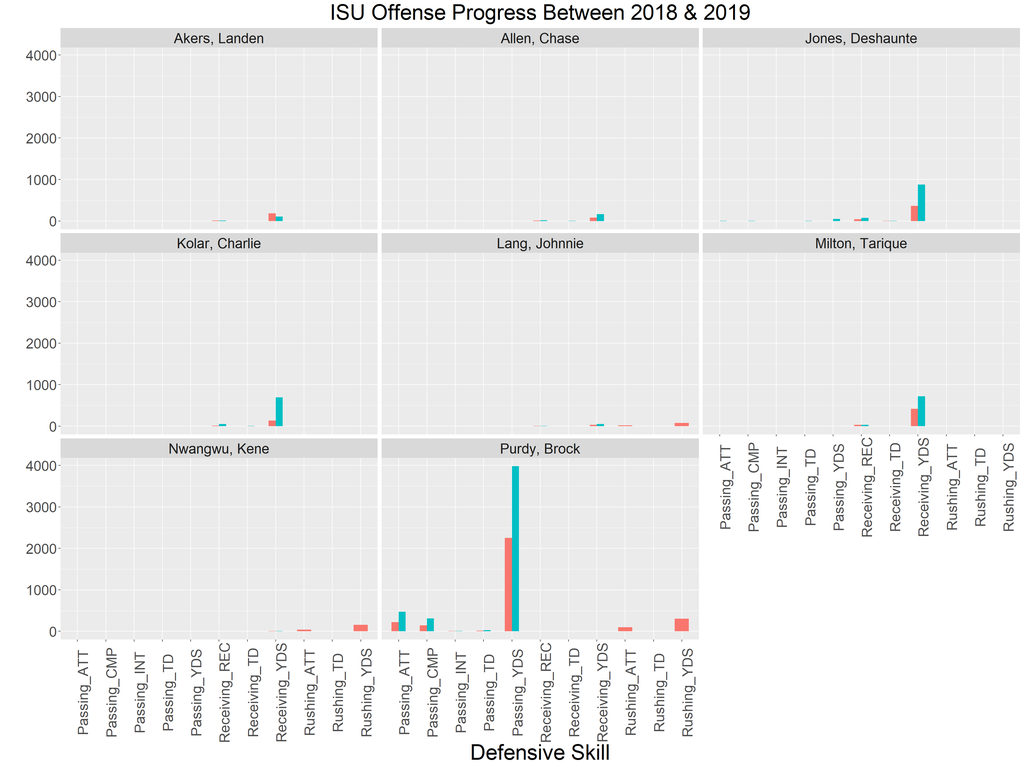

```r
offClean2N <- offense2 %>%
  select(Name) %>%
  distinct()

offClean3N <- offClean %>%
  select(Name) %>%
  distinct()

OffNames <- inner_join(offClean2N, offClean3N)

offClean2 <- offense2 %>%
  select(-Opponent_Opponent) %>%
  mutate(Name = as.factor(Name)) %>%
  separate(`Passing_CMP-ATT`, c('Passing_CMP', 'Passing_ATT')) %>%
  mutate(across(.cols = (Receiving_REC:Passing_INT), .fns = (as.numeric))) %>%
  group_by(Name) %>%
  summarise_at(vars(Receiving_REC:Passing_INT), sum, na.rm=TRUE) %>%
  mutate(Year = "2018") %>%
  right_join(OffNames) %>%
  pivot_longer('Receiving_REC':'Passing_INT', names_to='Off_Skill',
               values_to='Stat')

offClean3 <- offClean %>%
  select(-Opponent_Opponent) %>%
  group_by(Name) %>%
  summarise_at(vars(Receiving_REC:Passing_INT), sum, na.rm=TRUE) %>%
  mutate(Year='2019') %>%
  right_join(OffNames) %>%
  pivot_longer('Receiving_REC':'Passing_INT', names_to='Off_Skill',
               values_to='Stat')

offComp <- full_join(offClean2, offClean3)

ggplot(offComp, aes(Off_Skill, Stat, fill=Year)) +
  geom_bar(stat = "identity", position = 'dodge', width = 0.5) +
  ggtitle("ISU Offense Progress Between 2018 & 2019") +
  theme(plot.title = element_text(size = 30)) +
  theme(plot.title = element_text(hjust = 0.5)) +  theme(legend.position="none") +
  theme(axis.text = element_text(size = 20)) + theme(axis.title = element_text(size = 30)) +
  theme(axis.text.x = element_text(angle = 90)) + ylab("") +
  xlab("Defensive Skill") +  facet_wrap(~Name) +theme(strip.text.x = element_text(size = 20))
```